# final project

Jiayi Guo, Ziqu Wang, Yuanhao Zhu, Yuhan Hu, Michael Russo

4/18/2021

##data processing

```r
#We use the raw data in sheet 2 for data processing. The transformed data is ill structured. For instance ln1 is 0 and missing values were also assigned value 0.
library("readxl")
library("dplyr")
rawdata <- read_excel("COVID.xlsx", sheet = "Sheet2",col_names=T,range = cell_cols(1:9))
colnames(rawdata)<-c("CODE","COUNTRY",  "DATE", "TC",   "TD","STI", "POP","GDPCAP","HDI")
#a function take natrual log and leave 0 if the cell is 0 and NA if the cell is NA
avoid_zero_ln<-function(x){
 n=ifelse(x == 0, 0, log(x))
 return(n)
}

data<-rawdata %>% mutate_at(c("TC", "TD","STI", "POP","GDPCAP"), avoid_zero_ln)
colnames(data)<-c("CODE","COUNTRY", "DATE", "logTC",    "logTD","logSTI",   "logPOP","logGDPCAP","HDI")
#keep both variables in log scale and original ones.
#The processed data is  called covid. Note that NA values are perserved.
covid<-cbind(data,rawdata[,c(4:8)])
head(covid)
```

```
##   CODE     COUNTRY       DATE logTC logTD logSTI   logPOP logGDPCAP   HDI TC TD
## 1  AFG Afghanistan 2019-12-31     0     0      0 17.47723  7.497754 0.498  0  0
## 2  AFG Afghanistan 2020-01-01     0     0      0 17.47723  7.497754 0.498  0  0
## 3  AFG Afghanistan 2020-01-02     0     0      0 17.47723  7.497754 0.498  0  0
## 4  AFG Afghanistan 2020-01-03     0     0      0 17.47723  7.497754 0.498  0  0
## 5  AFG Afghanistan 2020-01-04     0     0      0 17.47723  7.497754 0.498  0  0
## 6  AFG Afghanistan 2020-01-05     0     0      0 17.47723  7.497754 0.498  0  0
##   STI      POP   GDPCAP
## 1   0 38928341 1803.987
## 2   0 38928341 1803.987
## 3   0 38928341 1803.987
## 4   0 38928341 1803.987
## 5   0 38928341 1803.987
## 6   0 38928341 1803.987
```

> Data are in both natural log and original scale.

| Variable Indicator | Description | Measurement |
| --- | --- | --- |
| STI | Stringency Index | COVID-19 PandemicLockdown |
| TC | Total Cases | COVID-19 PandemicTotal cases recorded |
| TD | Total Death | COVID-19 PandemicDeaths- |
| GDPCAP | GDP Per Capital | Economic Growth |
| HDI | Human Development Index | Poverty Alleviation |

```r
library("ggplot2")
theme_set(theme_bw())
library("sf")
library("rnaturalearth")
library("rnaturalearthdata")
library("maps")
world_map <- map_data("world")
```

```r
world_map <- map_data("world")
deathrate<-c()
for( i in unique(covid$COUNTRY)){
  d<-covid[covid$COUNTRY==i,11]
  p<-covid[covid$COUNTRY==i,13]
  if(all(is.na(p)) |all(is.na(d)) ){rate<-NA}
  else{
  totaldeath<-max(d,na.rm=T)
  population<-max(p,na.rm = T)
  rate<-(totaldeath/population)*100}
  deathrate<-c(deathrate,rate)
}
d_rate<-data.frame(region=unique(covid$COUNTRY), deathrate)
levels(d_rate$region)[levels(d_rate$region)=="United States"] <- "USA"
```

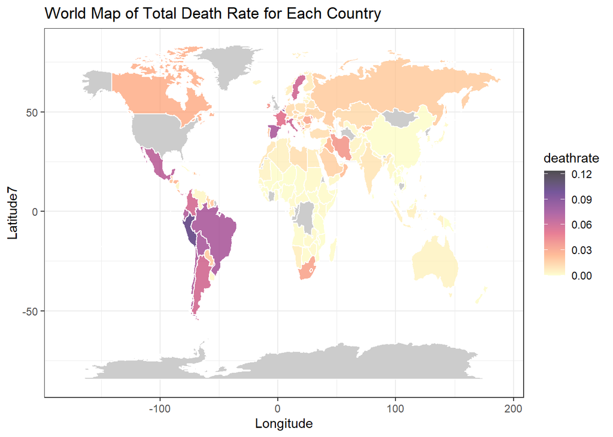

```r
comb <- left_join(world_map,d_rate, by = "region")
ggplot(comb, aes(long, lat, group = group))+
  geom_polygon(aes(fill = deathrate ), color = "white")+
  scale_fill_viridis_c(
  alpha = 0.7,
  begin = 0,
  end = 1,
  direction = -1,
  option = "A",
  values = NULL,
  space = "Lab",
  na.value = "grey80",
  guide = "colourbar",
  aesthetics = "fill"
)+labs(title="World Map of Total Death Rate for Each Country",
        x ="Longitude", y = "Latitude7")
```

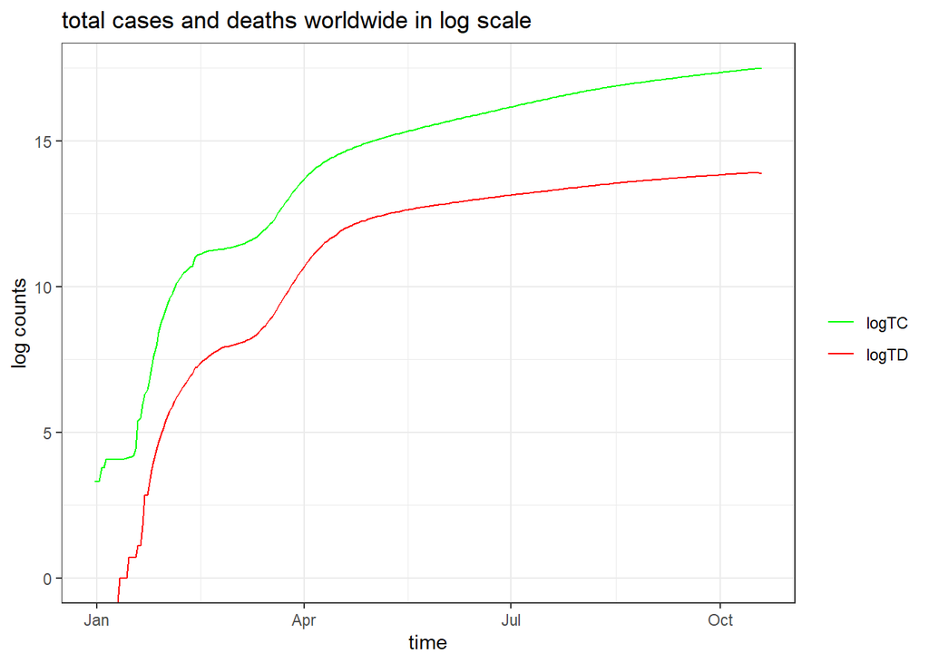

```r
# plot trend of covid cases and death world wide
sub_covid<-covid[,c('DATE',"TC","TD")]

sub_covid$FDATE<-as.factor(sub_covid$DATE)
world_cases<-aggregate(TC~FDATE, data=sub_covid, FUN=sum ,na.action=na.omit)
world_death<-aggregate(TD~FDATE, data=sub_covid, FUN=sum ,na.action=na.omit)
world_death<-subset(world_death, select = -c(1) )
world_cd<-cbind(world_cases,world_death)
world_cd$logTC<-log(world_cd$TC)
world_cd$logTD<-log(world_cd$TD)
ggplot(data = world_cd, aes(x = as.Date(FDATE))) +
  geom_line(aes(y = logTC, colour = "logTC")) +
  geom_line(aes(y = logTD, colour = "logTD")) +
  scale_colour_manual("", values = c("logTC"="green", "logTD"="red")) +
  xlab("time") +
  ylab("log counts")+
  labs(title="total cases and deaths worldwide in log scale")
```

```r
#plot correlation between GDP VS STI AND
deathrate<-c()
for( i in unique(covid$COUNTRY)){
  d<-covid[covid$COUNTRY==i,11]
  p<-covid[covid$COUNTRY==i,13]
  if(all(is.na(p)) |all(is.na(d)) ){rate<-NA}
  else{
  totaldeath<-max(d,na.rm=T)
  population<-max(p,na.rm = T)
  rate<-(totaldeath/population)*100}
  deathrate<-c(deathrate,rate)
}
```

```r
#correlation of total death vs HDI is different for underdeveloped developing and developed countries, result of the paper may be wrong!
quantile(covid$GDPCAP,na.rm=T)
```

```
##         0%        25%        50%        75%       100%
##    661.240   5338.454  13913.839  31400.840 116935.600
```

```r
bygdp<-covid[,c('COUNTRY',"TD","GDPCAP","HDI")]
bygdp$type[bygdp$GDPCAP<5338.454]<-"UNDERDEVELOPED"
bygdp$type[bygdp$GDPCAP> 5338.454 &bygdp$GDPCAP<31400.840]<-"DEVELOPING"
bygdp$type[bygdp$GDPCAP>31400.840 ]<-"DEVELOPED"
ud<-bygdp[bygdp$type=="UNDERDEVELOPED",]
d<-bygdp[bygdp$type=="DEVELOPING",]
dd<-bygdp[bygdp$type=="DEVELOPED",]
ud_corr<-cor(ud$TD,ud$HDI,use="pairwise.complete.obs")
d_corr<-cor(d$TD,d$HDI,use="pairwise.complete.obs")
dd_corr<-cor(dd$TD,dd$HDI,use="pairwise.complete.obs")
ud_p<-cor.test(ud$TD,ud$HDI,use="pairwise.complete.obs")$p.value
d_p<-cor.test(d$TD,d$HDI,use="pairwise.complete.obs")$p.value
dd_p<-cor.test(dd$TD,dd$HDI,use="pairwise.complete.obs")$p.value
data.frame(type=c("underdeveloped","developing","developed"),corrs=c(ud_corr,d_corr,dd_corr),pval=c(ud_p,d_p,dd_p))
```

```
##             type      corrs         pval
## 1 underdeveloped 0.20260443 1.089498e-86
## 2     developing 0.01209553 1.157594e-01
## 3      developed 0.10965250 2.521574e-22
```

> In comparison to the paper, we find although in general total death has a positive correlation with HDI, the effect is insignificant for developing country, but is significant for underdeveloped, developed countries. Thus, we can think population control may not be a good idea for developing countries. Also for further regression analysis , we may need to create indicator variable for the degree of developement for countries.

##Regression part

```r
library(tidyverse)
covid$DATE <- as.Date(covid$DATE , format = "%Y-%m-%d")

#function to calculate mortality rate, return 0 if no case or if no death
mrate<-function(td,tc){
  if (td==0){mortality<-0}
  else{mortality<-td/tc}
  return (mortality)

}
```

```r
# Time Phase
begin_phase = as.Date("2020-02-01", format = "%Y-%m-%d")
dev_phase = as.Date("2020-05-01", format = "%Y-%m-%d")
outbreak_phase = as.Date("2020-07-01", format = "%Y-%m-%d")
regressiondata <- covid %>%  mutate(PHASE = case_when(
  DATE<=begin_phase ~ 0,
  DATE> begin_phase &DATE <=dev_phase ~ 1,
  DATE>=dev_phase ~ 2
))%>% filter(DATE==begin_phase |DATE==dev_phase|DATE==outbreak_phase)
regressiondata$TYPE[regressiondata$GDPCAP<5338.454]<-"UNDERDEVELOPED"
regressiondata$TYPE[regressiondata$GDPCAP>= 5338.454 & regressiondata$GDPCAP<31400.840]<-"DEVELOPING"
covid$TYPE[covid$GDPCAP>=31400.840 ]<-"DEVELOPED"
regressiondata<-drop_na(regressiondata)
regressiondata$mortality_rate<-as.vector(mapply(mrate,regressiondata$TD,regressiondata$TC))*100
regressiondata$PHASE<-as.factor(regressiondata$PHASE)
regressiondata$TYPE<-as.factor(regressiondata$TYPE)
regressiondata$GDP<- regressiondata$POP *regressiondata$GDPCAP
regressiondata$logGDP<- log(regressiondata$POP *regressiondata$GDPCAP)
head(regressiondata)
```

```
##   CODE     COUNTRY       DATE     logTC    logTD   logSTI   logPOP logGDPCAP
## 1  AFG Afghanistan 2020-02-01  0.000000 0.000000 0.000000 17.47723  7.497754
## 2  AFG Afghanistan 2020-05-01  7.682943 4.158883 4.433907 17.47723  7.497754
## 3  AFG Afghanistan 2020-07-01 10.358282 6.614726 4.365643 17.47723  7.497754
## 4  ALB     Albania 2020-05-01  6.650279 3.433987 4.497696 14.87254  9.376146
## 5  ALB     Albania 2020-07-01  7.837949 4.127134 4.171460 14.87254  9.376146
## 6  DZA     Algeria 2020-05-01  8.295549 6.109248 4.341855 17.59631  9.540639
##     HDI    TC  TD   STI      POP    GDPCAP PHASE           TYPE mortality_rate
## 1 0.498     0   0  0.00 38928341  1803.987     0 UNDERDEVELOPED       0.000000
## 2 0.498  2171  64 84.26 38928341  1803.987     1 UNDERDEVELOPED       2.947950
## 3 0.498 31517 746 78.70 38928341  1803.987     2 UNDERDEVELOPED       2.366977
## 4 0.785   773  31 89.81  2877800 11803.431     1     DEVELOPING       4.010349
## 5 0.785  2535  62 64.81  2877800 11803.431     2     DEVELOPING       2.445759
## 6 0.754  4006 450 76.85 43851043 13913.839     1     DEVELOPING      11.233150
##            GDP   logGDP
## 1  70226221096 24.97499
## 2  70226221096 24.97499
## 3  70226221096 24.97499
## 4  33967913732 24.24868
## 5  33967913732 24.24868
## 6 610136352284 27.13695
```

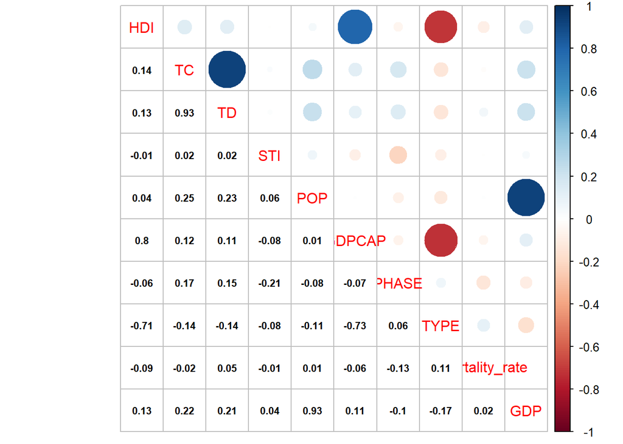

```r
library(corrplot)
corrdata <- regressiondata[c(9:18) ]
corrdata$TYPE <- as.numeric(factor(corrdata$TYPE))
corrdata$PHASE <-as.numeric(corrdata$PHASE)
cor1 = cor(corrdata)
corrplot.mixed(cor1, lower.col = 'black', number.cex = .7)
```

##Regression Analysis

```r
library("MASS")
#use robust regression method
robust_regression_m1<-rlm(GDPCAP ~ TC+TD +logPOP+HDI+ STI:TYPE+STI:PHASE, data = regressiondata)
summary(robust_regression_m1)
```

```
##
## Call: rlm(formula = GDPCAP ~ TC + TD + logPOP + HDI + STI:TYPE + STI:PHASE,
##     data = regressiondata)
## Residuals:
##     Min      1Q  Median      3Q     Max
## -7999.3 -2658.0  -299.9  2661.5 27646.5
##
## Coefficients:
##                        Value       Std. Error  t value
## (Intercept)            -13240.9329   3959.6361     -3.3440
## TC                          0.0082      0.0069      1.1965
## TD                         -0.1609      0.1668     -0.9644
## logPOP                   -151.0572    201.7189     -0.7489
## HDI                     43944.9261   2615.3484     16.8027
## STI:TYPEDEVELOPING        -17.6792     60.7115     -0.2912
## STI:TYPEUNDERDEVELOPED    -46.7525     61.7074     -0.7576
## STI:PHASE1                 -8.5240     59.3390     -0.1436
## STI:PHASE2                -18.8800     59.5945     -0.3168
##
## Residual standard error: 3979 on 218 degrees of freedom
```

```r
regression_m1<-lm(GDPCAP ~ TC+TD +logPOP+HDI+ STI:TYPE+STI:PHASE, data = regressiondata)
summary(regression_m1)
```

```
##
## Call:
## lm(formula = GDPCAP ~ TC + TD + logPOP + HDI + STI:TYPE + STI:PHASE,
##     data = regressiondata)
##
## Residuals:
##     Min      1Q  Median      3Q     Max
## -7942.4 -3279.5  -478.9  2217.2 19923.7
##
## Coefficients:
##                          Estimate Std. Error t value Pr(>|t|)
## (Intercept)            -2.213e+03  4.272e+03  -0.518   0.6049
## TC                      1.057e-02  7.400e-03   1.429   0.1545
## TD                     -1.916e-01  1.800e-01  -1.064   0.2883
## logPOP                 -4.245e+02  2.176e+02  -1.950   0.0524 .
## HDI                     3.501e+04  2.822e+03  12.406   <2e-16 ***
## STI:TYPEDEVELOPING      9.579e-01  6.550e+01   0.015   0.9883
## STI:TYPEUNDERDEVELOPED -6.062e+01  6.657e+01  -0.911   0.3636
## STI:PHASE1             -1.827e+01  6.402e+01  -0.285   0.7756
## STI:PHASE2             -3.118e+01  6.430e+01  -0.485   0.6282
## ---
## Signif. codes:  0 '***' 0.001 '**' 0.01 '*' 0.05 '.' 0.1 ' ' 1
##
## Residual standard error: 4812 on 218 degrees of freedom
## Multiple R-squared:  0.6897, Adjusted R-squared:  0.6783
## F-statistic: 60.56 on 8 and 218 DF,  p-value: < 2.2e-16
```

```r
stepAIC(regression_m1,direction="both")
```

```
## Start:  AIC=3858.21
## GDPCAP ~ TC + TD + logPOP + HDI + STI:TYPE + STI:PHASE
##
##             Df  Sum of Sq        RSS    AIC
## - STI:PHASE  2   45365482 5092847092 3856.2
## - TD         1   26236432 5073718042 3857.4
## <none>                    5047481610 3858.2
## - TC         1   47270342 5094751952 3858.3
## - logPOP     1   88079132 5135560742 3860.1
## - STI:TYPE   2  599492332 5646973942 3879.7
## - HDI        1 3563519127 8611000738 3977.5
##
## Step:  AIC=3856.24
## GDPCAP ~ TC + TD + logPOP + HDI + STI:TYPE
##
##             Df  Sum of Sq        RSS    AIC
## - TD         1   22996022 5115843115 3855.3
## - TC         1   35491725 5128338818 3855.8
## <none>                    5092847092 3856.2
## - logPOP     1   80568029 5173415122 3857.8
## + STI:PHASE  2   45365482 5047481610 3858.2
## - STI:TYPE   2  711207215 5804054307 3881.9
## - HDI        1 3621322793 8714169886 3976.2
##
## Step:  AIC=3855.26
## GDPCAP ~ TC + logPOP + HDI + STI:TYPE
##
##             Df  Sum of Sq        RSS    AIC
## - TC         1   15142207 5130985321 3853.9
## <none>                    5115843115 3855.3
## + TD         1   22996022 5092847092 3856.2
## - logPOP     1   80521809 5196364924 3856.8
## + STI:PHASE  2   42125073 5073718042 3857.4
## - STI:TYPE   2  702592174 5818435288 3880.5
## - HDI        1 3634813915 8750657030 3975.1
##
## Step:  AIC=3853.93
## GDPCAP ~ logPOP + HDI + STI:TYPE
##
##             Df  Sum of Sq        RSS    AIC
## <none>                    5130985321 3853.9
## - logPOP     1   66223960 5197209281 3854.8
## + TC         1   15142207 5115843115 3855.3
## + TD         1    2646503 5128338818 3855.8
## + STI:PHASE  2   28516821 5102468500 3856.7
## - STI:TYPE   2  717125427 5848110748 3879.6
## - HDI        1 3702629294 8833614615 3975.3
```

```
##
## Call:
## lm(formula = GDPCAP ~ logPOP + HDI + STI:TYPE, data = regressiondata)
##
## Coefficients:
##            (Intercept)                  logPOP                     HDI
##               -4319.26                 -338.24                35482.01
##     STI:TYPEDEVELOPING  STI:TYPEUNDERDEVELOPED
##                 -15.91                  -78.47
```